# Final: Ice Cream

Alonso Romero, Russ Ballard

2024-04-28

# The Ice Cream Dataset

Our project uses an Ice Cream dataset that was retrieved from Kaggle from the following website: “https://www.kaggle.com/datasets/tysonpo/ice-cream-dataset/data”. The dataset contains a product and review datasets for 4 brands of ice cream, Ben & Jerry’s, Häagen-Dazs, Talenti, and Breyers. For the purposes of this project, we will be using a combined dataset provided by the author that combines all the products and reviews of all brands into their respective csv file.

```r
brandcolorpath <- file.path(projwd, datadir, "processing/brandcolors.csv")
brandcolordf <- data.frame(read.csv(brandcolorpath,
                           header=TRUE,
                           sep=",",
                           quote="\"",
                           colClasses=c("brand"="character",
                                        "color"="character",
                                        "fill"="character")))
```

A metadata table containing color choices for the different brands has been created, this abstraction can be used for setting colors in the subsequent visualizations for standardizaiton and ease of implementation.

```r
ingredientpath <- file.path(projwd, datadir, "processing/ingredientrenamedict.csv")
ingredientrenamedf <- data.frame(read.csv(ingredientpath,
                           header=TRUE,
                           sep=",",
                           quote="\"",
                           colClasses=c("from_ingredient"="character",
                                        "to_ingredient"="character")))

head(ingredientrenamedf)
```

[output not shown]

A metadata table containing ingredient mappings. This dataframe can be used in precleaning to reduce the number of ingredients in the ingredients field and strips special characters.

```r
prodcombpath <- file.path(outpath, "combined/products.csv")
products <- data.frame(read.csv(prodcombpath,
                            header=TRUE,
                            sep=",",
                            quote="\"",
                            colClasses=c("brand"="factor",
                                          "key"="character",
                                          "name"="character",
                                          "subhead"="character",
                                          "description"="character",
                                          "rating"="numeric",
                                          "rating_count"="numeric",
                                          "ingredients"="character")))
products <- products %>% mutate_if(is.character, utf8::utf8_encode)
```

```r
reviewpath <- file.path(outpath, "combined/reviews.csv")
reviews <- data.frame(read.csv(reviewpath,
                            header=TRUE,
                            sep=",",
                            quote="\"",
                            na.strings=c("","NA"),
                            colClasses=c("brand"="factor",
                                          "key"="character",
                                          "author"="character",
                                          "date"="character",
                                          "stars"="factor",
                                          "title"="character",
                                          "helpful_yes"="numeric",
                                          "helpful_no"="character",
                                          "text"="character",
                                          "taste"="numeric",
                                          "ingredients"="numeric",
                                          "texture"="character",
                                          "likes"="character")))
reviews <- reviews %>% mutate_if(is.character, utf8::utf8_encode)
reviews$date <- as.Date(reviews$date,'%Y-%m-%d')
```

```r
nrow_products <- nrow(products)
nrow_reviews <- nrow(reviews)
```

Here we load the `products` and `reviews` datasets, explicitly declaring dataframe field types, and cleaning the data of any characters which are not utf-8 encoded. The combined product dataset contains 241 data points, and the combined reviews dataset contains 21674 data points.

For the `products.csv` file, the variables in the dataset are:

- `brand`: brand keyword that categorizes each product to its respective brand
- `key`: the primary key that contains a numerical value and the brand keyword
- `name`: the product name
- `subhead`: simple description of the product (used for Ben & Jerry’s products only)
- `description`: detailed description of the product
- `rating`: a star rating scale with a range of 1.0 to 5.0
- `rating_count`: amount of ratings for the product
- `ingredients`: ingredient list of the product

For the `reviews.csv` file, the variables in the dataset are:

- `brand`: brand keyword that categorizes each product to its respective brand
- `key`: foreign key that matches to key in `products.csv`
- `author`: the username of the reviewer
- `date`: date that review was posted
- `stars`: reviewer rating of the product
- `title`: reviewer-created title of their review
- `helpful_yes`: amount of users that found the review helpful
- `helpful_no`: amount of users that found the review not helpful
- `text`: the text-based review
- `taste`: reviewer rating of product taste in a range of 1.0 to 5.0 (For Häagen-Dazs products only)
- `ingredients`: reviewer rating of product ingredients in a range of 1.0 to 5.0 (For Häagen-Dazs products only)
- `texture`: reviewer rating of product texture in a range of 1.0 to 5.0 (For Häagen-Dazs products only)
- `likes`: reviewer likes from a preset list to choose from (For Häagen-Dazs products only)

Regarding the dataset, there are important considerations that the author provides for users. First, “the collection of reviews on the brand websites may not be representative of overall opinion, i.e. there may be review censoring or presence of fake reviews meant to help/harm the image of the brand” (Pond, 2020). In order to combat this, the author, “intentionally chose brands that host some negative reviews on their website” (Pond, 2020). Next, the author acknowledges the parent companies of each of the brands. “Ben & Jerry’s, Breyers, and Talenti are all owned by Uniever. Häagen-Dazs is owned by Froneri” (Pond, 2020). It is also important to note that, “Talenti is distinguished from the other brands as they produce gelato” (Pond, 2020).

```r
xkablesummary(products, title = "Summary of the products dataset")
```

Summary of the products dataset

|  | Brand | ProductID | ProductName | Subhead | ProductDescription | Rating | RatingCount | Ingredients |
| --- | --- | --- | --- | --- | --- | --- | --- | --- |
| Min | bj :57 | Length:241 | Length:241 | Length:241 | Length:241 | Min. :1.20 | Min. : 2 | Length:241 |
| Q1 | breyers:69 | Class :character | Class :character | Class :character | Class :character | 1st Qu.:4.00 | 1st Qu.: 28 | Class :character |
| Median | hd :70 | Mode :character | Mode :character | Mode :character | Mode :character | Median :4.40 | Median : 59 | Mode :character |
| Mean | talenti:45 | NA | NA | NA | NA | Mean :4.22 | Mean : 90 | NA |
| Q3 | NA | NA | NA | NA | NA | 3rd Qu.:4.70 | 3rd Qu.:112 | NA |
| Max | NA | NA | NA | NA | NA | Max. :5.00 | Max. :983 | NA |

```r
xkablesummary(reviews, title = "Summary of the reviews dataset")
```

Summary of the reviews dataset

|  | Brand | ProductID | Username | Date | Stars | Title | Helpful | Not Helpful | Review | Taste | IngredientsDesc | Texture | Likes |
| --- | --- | --- | --- | --- | --- | --- | --- | --- | --- | --- | --- | --- | --- |
| Min | bj :7943 | Length:21674 | Length:21674 | Min. :2015-10-27 | 1: 2404 | Length:21674 | Min. : 0 | Length:21674 | Length:21674 | Min. :1 | Min. :1 | Length:21674 | Length:21674 |
| Q1 | breyers:5007 | Class :character | Class :character | 1st Qu.:2018-05-17 | 2: 1131 | Class :character | 1st Qu.: 0 | Class :character | Class :character | 1st Qu.:4 | 1st Qu.:4 | Class :character | Class :character |
| Median | hd :4655 | Mode :character | Mode :character | Median :2019-04-03 | 3: 1060 | Mode :character | Median : 0 | Mode :character | Mode :character | Median :5 | Median :5 | Mode :character | Mode :character |
| Mean | talenti:4069 | NA | NA | Mean :2019-02-17 | 4: 1691 | NA | Mean : 1 | NA | NA | Mean :4 | Mean :4 | NA | NA |
| Q3 | NA | NA | NA | 3rd Qu.:2020-04-02 | 5:15388 | NA | 3rd Qu.: 1 | NA | NA | 3rd Qu.:5 | 3rd Qu.:5 | NA | NA |
| Max | NA | NA | NA | Max. :2020-10-04 | NA | NA | Max. :421 | NA | NA | Max. :5 | Max. :5 | NA | NA |
| NA | NA | NA | NA | NA | NA | NA | NA | NA | NA | NA’s :17409 | NA’s :17409 | NA | NA |

Above we review summaries of the `products` and `reviews` datasets.

```r
products$HAS_VANILLA <- as.factor(as.integer(grepl(pattern = "VANILLA", x = products$Ingredients)))
products$HAS_ORGANIC <- as.factor(as.integer(grepl(pattern = "ORGANIC", x = products$Ingredients)))
products$HAS_CARAMEL <- as.factor(as.integer(grepl(pattern = "CARAMEL", x = products$Ingredients)))

fruitvec <- c("RASPBERR","CHERR","BLUEBERR","BANANA")
products$HAS_FRUIT <- as.factor(as.integer(grepl(pattern=paste(fruitvec,collapse="|"), x=products$Ingredients)))

chocvec <- c("CHOCOLAT","COCO")
products$HAS_CHOCOLATE <- as.factor(as.integer(grepl(pattern=paste(chocvec,collapse="|"), x=products$Ingredients)))

products$IS_BAR <- as.factor(as.integer(grepl(pattern = "\\bBAR\\b", x = products$ProductName, ignore.case = TRUE) |
                                grepl(pattern = "\\bBAR\\b", x = products$Subhead, ignore.case = TRUE)))

products_bkp <- products
```

By using `grepl` we are able to create simple binary indicators for ingredient content in the icecream.

```r
productingredients <- unique(unlist(strsplit(products$Ingredients, ",")))

productingredients <- sapply(productingredients,trimws,USE.NAMES = FALSE)

productingredients <- str_sort(productingredients)
productingredients <- gsub('†',"",productingredients)

productingredients<-unique(productingredients)

ingredientprocessingdict2 <-filter(ingredientrenamedf, to_ingredient != "")

products$Ingredients <- stri_replace_all_fixed(products$Ingredients,
                                  pattern=ingredientprocessingdict2$from_ingredient,
                                  replacement=ingredientprocessingdict2$to_ingredient,
                                  vectorize=FALSE)
```

In this preprocessing step we convert the `products$ingredients` field from a single `character` entry into a vector of characters by treating commas in the `ingredients` field as a delimiter. We then use our `ingredientrenamedf` which contains string and string replacement values and was manually prepared by the data scientist to attempt to standardize the ingredient field in the `products$ingredients` field.

```r
products <- products[products$Brand=="breyers",]
reviews <- reviews[reviews$Brand=="breyers",]
```

Here we subset the data to only include icecream of the brand `Breyers`. This preprocessing step was elected to study the `Breyers` data more specifically for the application of MCA feature engineering and Linear Discriminant Analysis.

```r
product_sample <- sample(2, nrow(products), replace=TRUE, prob=c(0.67, 0.33))


product_training.labels <- products[product_sample==1, which(names(products) %in% c("Rating"))]
product_training <- products[product_sample==1, -which(names(products) %in% c("Rating"))]

product_test.labels <- products[product_sample==2, which(names(products) %in% c("Rating"))]
product_test <- products[product_sample==2, -which(names(products) %in% c("Rating"))]
```

We split the `product` dataset into training and testing. This is perhaps a bit early, or we could otherwise leave the data combined and subset the data using the `product_sample` vector at a later time.

```r
review_training.labels <- reviews[reviews$ProductID %in% product_training$ProductID,
                          which(names(products) %in% c("Rating"))]
review_training <- reviews[reviews$ProductID %in% product_training$ProductID,
                           -which(names(products) %in% c("Rating"))]


review_test.labels <- reviews[reviews$ProductID %in% product_test$ProductID,
                          which(names(products) %in% c("Rating"))]
review_test <- reviews[reviews$ProductID %in% product_test$ProductID,
                           -which(names(products) %in% c("Rating"))]
```

Similar to above, but for the `reviews` dataset.

```r
productreview <- left_join(reviews,
                           products %>% dplyr::select(ProductID,
                                                 HAS_CARAMEL,
                                                 HAS_CHOCOLATE,
                                                 HAS_FRUIT,
                                                 HAS_VANILLA,
                                                 HAS_ORGANIC,
                                                 IS_BAR,
                                                 Ingredients),
                           by="ProductID", multiple="all")

productreview_bkp <- productreview

productreview_training <- (left_join(review_training,
                           product_training %>% dplyr::select(ProductID,
                                                 HAS_CARAMEL,
                                                 HAS_CHOCOLATE,
                                                 HAS_FRUIT,
                                                 HAS_VANILLA,
                                                 HAS_ORGANIC,
                                                 IS_BAR,
                                                 Ingredients),
                           by="ProductID", multiple="all"))

productreview_test <- (left_join(review_test,
                           product_test %>% dplyr::select(ProductID,
                                                 HAS_CARAMEL,
                                                 HAS_CHOCOLATE,
                                                 HAS_FRUIT,
                                                 HAS_VANILLA,
                                                 HAS_ORGANIC,
                                                 IS_BAR,
                                                 Ingredients),
                           by="ProductID", multiple="all"))
```

This operation creates a combined `products` and `reviews` dataframe with ingredient content for each review as well as microdata for the `review` `Stars` rating rather than `product`’s aggregate mean rating.

```r
#Leave github issue here as a note: #factominer issue: https://github.com/husson/FactoMineR/issues/15
#TODO: open PR re: fix matrix transpose issue in FactoMineR

add_names_to_values = function(x,colname){
return(paste0(colname,"_",x))
}

preprocess_mca = function(base, preguntas){

base_char = apply(base[,preguntas],2,as.factor)
base_char = as.data.frame(base_char)
for ( col in colnames(base_char))
{
base_char[col] = apply(base_char[col],2,add_names_to_values,colname=col)
}
return(base_char)
}
```

There is a known issue with `FactoMineR` `predict.MCA()` function which causes it to create matrices which are not calcuable for cross-products. This presents an opportunity for contributing to the FactoMineR source, which the data scientist intends to do in the near future.

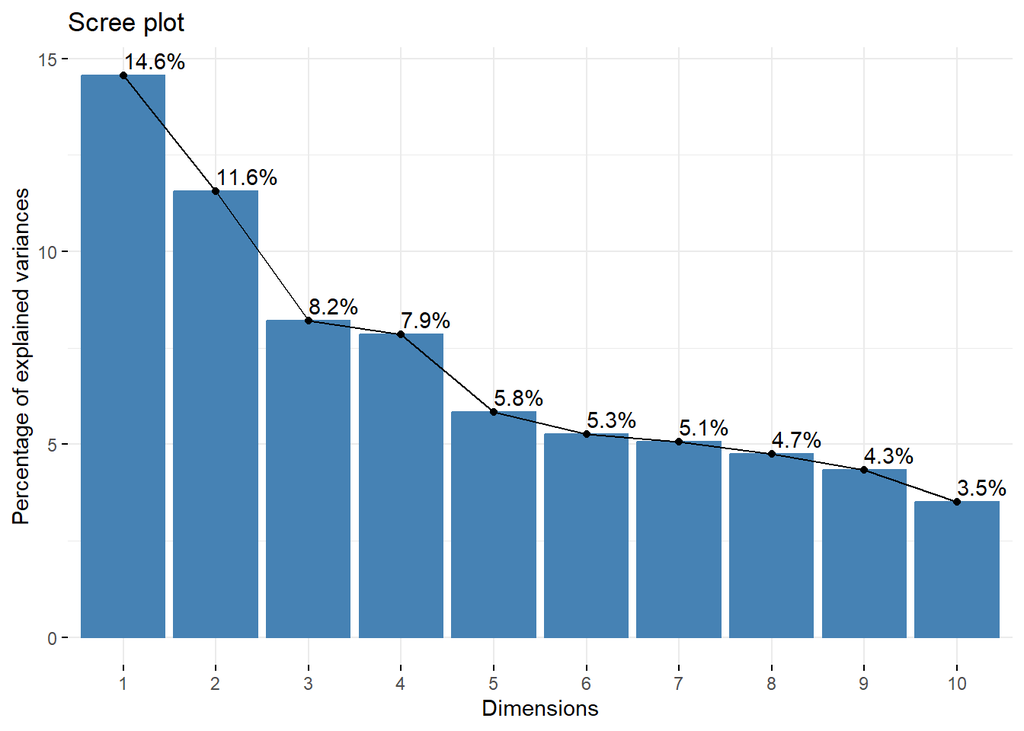

```r
#Create one-hot matrix for ingredients in Breyers products.
ingredindicator <- products %>%
                   rownames_to_column(var="row") %>%
                   separate_rows(Ingredients, sep=",") %>%
                   mutate(Ingredients = str_squish(Ingredients)) %>%
                   count(row, Ingredients) %>%
                   spread(Ingredients, n, fill = 0)


#"row" is added artifactually in the course of the one-hot matrix formulation and is dropped, we also cast duplicative ingredient listings to 1's i.e., has ingredient.
ingredindicator <- ingredindicator[ ,-which(names(ingredindicator) %in% c("row")) ]
ingredindicator[ingredindicator > 0] <- 1

ingredindicator$traintest <- product_sample

#Here we create an aggregate table with indicator sums by train and test for each ingredient. We use this to identify non-contributing factors in either train or test. This was done in order to allow for cross products using FactoRMineR, again, this highlights a potential issue as in theory FactoMineR SVD should already be eliminating these non-contributing factors.

ingredcounts <- aggregate(.~traintest,ingredindicator,sum)
ingrednozeros <- ingredcounts %>% dplyr::select(where(~ all(. != 0)))
ingrednozeros <- colnames(ingrednozeros)

col_names <- names(ingredindicator)
ingredindicator <- ingredindicator %>%
  mutate(across(all_of(col_names), as.factor))

ingredindicator <- ingredindicator[,-which(names(ingredindicator) %in% c("traintest"))]

#ingred_training <- ingredindicator[product_sample==1,]
ingred_training <- ingredindicator[product_sample==1,]

ingred_training <- ingred_training[,which(names(ingred_training) %in% ingrednozeros)]
train.cats = apply(ingred_training, 2, function(x) nlevels(as.factor(x)))

ingred_test <- ingredindicator[product_sample==2,]

ingred_test <- ingred_test[,which(names(ingred_test) %in% ingrednozeros)]
test.cats = apply(ingred_test, 2, function(x) nlevels(as.factor(x)))

ingred_mca <- MCA(ingred_training, graph = FALSE)

ingred_test.preprocess <- preprocess_mca(ingred_test)
ingred_predict <- predict.MCA(object = ingred_mca,
            newdata = ingred_test.preprocess)

cumvar <- with(ingred_mca, eig[5,'cumulative percentage of variance'])

fviz_screeplot(ingred_mca, addlabels = TRUE)
```

Here we fit an MCA model to the `products` dataset. **M**ultiple **C**orrespondence **A**nalysis is a feature engineering methodology for extracting eigenvectors from a matrix of row-factor levels rather than numeric values as is the case with PCA. This method is ideal for distilling features in the one-hot encoded `ingredient` `products` data. We see reviewing the scree plot that the first `5` eigen-values encode 48.036 percent of the variance in the training data. This allows us to drastically reduce the complexity of our `LDA` model in the next section.

```r
ingred_training.mcadim <- as.data.frame(ingred_mca$ind$coord)

ingred_training.mcadim['ProductID'] <- product_training['ProductID']
ingred_training.mcadim['avg_ratings']<-product_training.labels

productreview_training <- left_join(productreview_training,
                                   ingred_training.mcadim %>% dplyr::select('Dim 1',
                                                                     'Dim 2',
                                                                     'Dim 3',
                                                                     'Dim 4',
                                                                     'Dim 5',
                                                                     ProductID),
                                   by="ProductID",multiple="all")

productreview_training <- productreview_training %>%
                           rename("Dim_1"='Dim 1',
                                 "Dim_2"='Dim 2',
                                 "Dim_3"='Dim 3',
                                 "Dim_4"='Dim 4',
                                 "Dim_5"='Dim 5')

lda.fit <- MASS::lda(grouping=productreview_training$Stars, x=productreview_training[,c('Dim_1','Dim_2' ,'Dim_3','Dim_4','Dim_5')])

#lda.fit$prior

ingred_test.mcadim <- as.data.frame(ingred_predict$coord)
ingred_test.mcadim['ProductID'] <- product_test['ProductID']
ingred_test.mcadim['avg_ratings']<-product_test.labels

productreview_test <- left_join(productreview_test,
                                   ingred_test.mcadim %>% dplyr::select('Dim 1',
                                                                     'Dim 2',
                                                                     'Dim 3',
                                                                     'Dim 4',
                                                                     'Dim 5',
                                                                     ProductID),
                                   by="ProductID",multiple="all")

productreview_test <- productreview_test %>%
                           rename("Dim_1"='Dim 1',
                                 "Dim_2"='Dim 2',
                                 "Dim_3"='Dim 3',
                                 "Dim_4"='Dim 4',
                                 "Dim_5"='Dim 5')

productreview_test_prep <- productreview_test[c('Dim_1','Dim_2','Dim_3','Dim_4','Dim_5')]

lda.pred <- predict(lda.fit,productreview_test_prep)

productreview_test$pred <- lda.pred$class

table(productreview_test$pred,productreview_test$Stars)
```

```
##
##       1   2   3   4   5
##   1   2   1   1   2  22
##   2   0   0   0   0   0
##   3   0   0   0   0   0
##   4   0   0   0   0   0
##   5 192  74  65 170 896
```

```r
table(productreview_test$Stars)
```

```
##
##   1   2   3   4   5
## 194  75  66 172 918
```

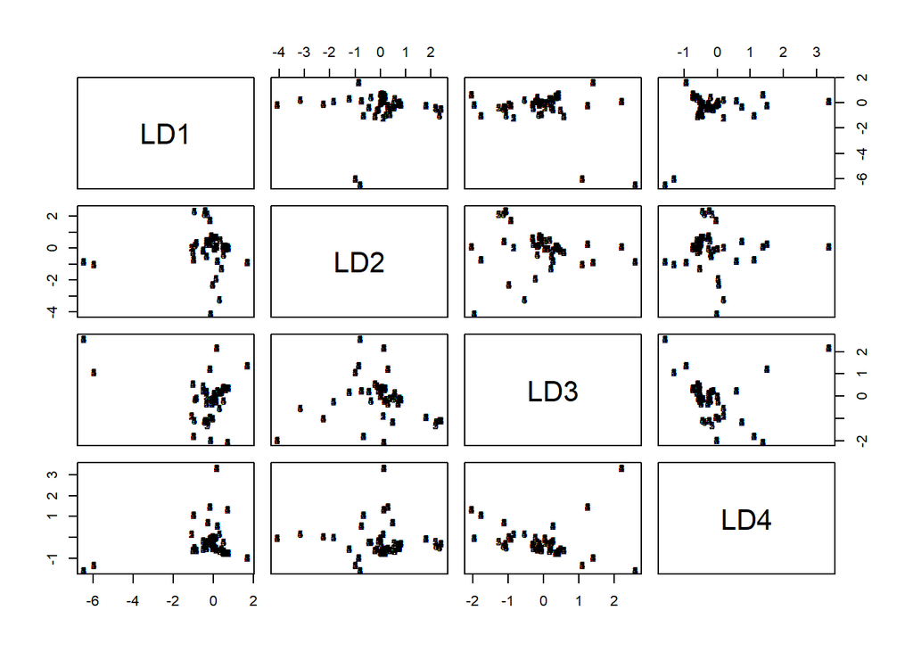

```r
cm <- confusionMatrix(lda.pred$class, reference = productreview_test$Stars )

plot(lda.fit)
```

```r
#cm$table

cm
```

```
## Confusion Matrix and Statistics
##
##           Reference
## Prediction   1   2   3   4   5
##          1   2   1   1   2  22
##          2   0   0   0   0   0
##          3   0   0   0   0   0
##          4   0   0   0   0   0
##          5 192  74  65 170 896
##
## Overall Statistics
##
##                Accuracy : 0.63
##                  95% CI : (0.605, 0.655)
##     No Information Rate : 0.644
##     P-Value [Acc > NIR] : 0.872
##
##                   Kappa : -0.011
##
##  Mcnemar's Test P-Value : NA
##
## Statistics by Class:
##
##                      Class: 1 Class: 2 Class: 3 Class: 4 Class: 5
## Sensitivity            0.0103   0.0000   0.0000    0.000   0.9760
## Specificity            0.9789   1.0000   1.0000    1.000   0.0118
## Pos Pred Value         0.0714      NaN      NaN      NaN   0.6414
## Neg Pred Value         0.8626   0.9474   0.9537    0.879   0.2143
## Prevalence             0.1361   0.0526   0.0463    0.121   0.6442
## Detection Rate         0.0014   0.0000   0.0000    0.000   0.6288
## Detection Prevalence   0.0196   0.0000   0.0000    0.000   0.9804
## Balanced Accuracy      0.4946   0.5000   0.5000    0.500   0.4939
```

With our Linear Discriminant Analysis we are able to develop a predictive model with an `Accuracy` of 0.63 when applied to the `product-ingredient` test set. Reviewing the confusion matrix generated by the `caret` `confusionMatrix` call we see that the uneven factor weights earlier highlighted come in to play in the trained model predictions. In cases besides reviews rated `5` the model is unfortunately insensitive. One avenue of further research for eliminating this bias would be removing reviews with `5` ratings and studying only ratings 1-4, or other subsetting/stratification methods to correct for bias in the `reviews` data.